# Predict Bike Sharing Demand with AutoGluon Template

## Step 3: Train a model using AutoGluon’s Tabular Prediction

Requirements:

- We are prediting `count`, so it is the label we are setting.
- Ignore `casual` and `registered` columns as they are also not present in the test dataset.
- Use the `root_mean_squared_error` as the metric to use for evaluation.
- Set a time limit of 10 minutes (600 seconds).
- Use the preset `best_quality` to focus on creating the best model.

```python
from autogluon.tabular import TabularPredictor

# Drop 'casual' and 'registered' since they are not in test data and leak info
train_data = train.drop(columns=['casual', 'registered'])

# Set up and train the predictor
predictor = TabularPredictor(label='count', eval_metric='root_mean_squared_error')\
    .fit(train_data=train_data, time_limit=600, presets='best_quality')
```

[output not shown]

[output cut: 30 more lines]

```
	'KNN': [{'weights': 'uniform', 'ag_args': {'name_suffix': 'Unif'}}, {'weights': 'distance', 'ag_args': {'name_suffix': 'Dist'}}],
}
AutoGluon will fit 2 stack levels (L1 to L2) ...
Fitting 108 L1 models, fit_strategy="sequential" ...
Fitting model: KNeighborsUnif_BAG_L1 ... Training model for up to 99.74s of the 149.63s of remaining time.
	-107.445	 = Validation score   (-root_mean_squared_error)
	0.03s	 = Training   runtime
	0.06s	 = Validation runtime
Fitting model: KNeighborsDist_BAG_L1 ... Training model for up to 94.55s of the 144.44s of remaining time.
	-89.9469	 = Validation score   (-root_mean_squared_error)
	0.02s	 = Training   runtime
	0.05s	 = Validation runtime
Fitting model: LightGBMXT_BAG_L1 ... Training model for up to 94.47s of the 144.36s of remaining time.
Will use sequential fold fitting strategy because import of ray failed. Reason: ray is required to train folds in parallel for TabularPredictor or HPO for MultiModalPredictor. A quick tip is to install via `pip install "ray>=2.10.0,<2.45.0"`
	Fitting 8 child models (S1F1 - S1F8) | Fitting with SequentialLocalFoldFittingStrategy
```

[output not shown]

```
	-131.9758	 = Validation score   (-root_mean_squared_error)
	58.16s	 = Training   runtime
	7.13s	 = Validation runtime
Fitting model: LightGBM_BAG_L1 ... Training model for up to 24.52s of the 74.41s of remaining time.
	Fitting 8 child models (S1F1 - S1F8) | Fitting with SequentialLocalFoldFittingStrategy
```

```
[1000]	valid_set's rmse: 129.274
[1000]	valid_set's rmse: 129.285
[1000]	valid_set's rmse: 135.098
[1000]	valid_set's rmse: 124.896
[1000]	valid_set's rmse: 134.058
[1000]	valid_set's rmse: 134.479
[1000]	valid_set's rmse: 136.511
```

```
	-131.8496	 = Validation score   (-root_mean_squared_error)
	12.15s	 = Training   runtime
	0.95s	 = Validation runtime
Fitting model: RandomForestMSE_BAG_L1 ... Training model for up to 10.33s of the 60.22s of remaining time.
	-119.5485	 = Validation score   (-root_mean_squared_error)
	15.06s	 = Training   runtime
	0.7s	 = Validation runtime
Fitting model: WeightedEnsemble_L2 ... Training model for up to 149.66s of the 43.79s of remaining time.
	Ensemble Weights: {'KNeighborsDist_BAG_L1': 1.0}
	-89.9469	 = Validation score   (-root_mean_squared_error)
	0.02s	 = Training   runtime
	0.0s	 = Validation runtime
Fitting 106 L2 models, fit_strategy="sequential" ...
Fitting model: LightGBMXT_BAG_L2 ... Training model for up to 43.75s of the 43.72s of remaining time.
	Fitting 8 child models (S1F1 - S1F8) | Fitting with SequentialLocalFoldFittingStrategy
```

```
[1000]	valid_set's rmse: 69.5159
[1000]	valid_set's rmse: 71.3133
[1000]	valid_set's rmse: 78.3544
[1000]	valid_set's rmse: 73.3059
[2000]	valid_set's rmse: 73.2329
[1000]	valid_set's rmse: 75.7703
[1000]	valid_set's rmse: 76.8744
[1000]	valid_set's rmse: 71.8442
[1000]	valid_set's rmse: 74.306
[2000]	valid_set's rmse: 73.5731
```

[output not shown]

[output cut: 45 more lines]

```
	'XT': [{'criterion': 'gini', 'ag_args': {'name_suffix': 'Gini', 'problem_types': ['binary', 'multiclass']}}, {'criterion': 'entropy', 'ag_args': {'name_suffix': 'Entr', 'problem_types': ['binary', 'multiclass']}}, {'criterion': 'squared_error', 'ag_args': {'name_suffix': 'MSE', 'problem_types': ['r…
	'KNN': [{'weights': 'uniform', 'ag_args': {'name_suffix': 'Unif'}}, {'weights': 'distance', 'ag_args': {'name_suffix': 'Dist'}}],
}
AutoGluon will fit 2 stack levels (L1 to L2) ...
Fitting 108 L1 models, fit_strategy="sequential" ...
Fitting model: KNeighborsUnif_BAG_L1 ... Training model for up to 275.30s of the 413.04s of remaining time.
	-101.5462	 = Validation score   (-root_mean_squared_error)
	0.04s	 = Training   runtime
	0.06s	 = Validation runtime
Fitting model: KNeighborsDist_BAG_L1 ... Training model for up to 275.17s of the 412.91s of remaining time.
	-84.1251	 = Validation score   (-root_mean_squared_error)
	0.03s	 = Training   runtime
	0.06s	 = Validation runtime
Fitting model: LightGBMXT_BAG_L1 ... Training model for up to 275.05s of the 412.79s of remaining time.
	Fitting 8 child models (S1F1 - S1F8) | Fitting with SequentialLocalFoldFittingStrategy
```

[output not shown]

```
	-131.4609	 = Validation score   (-root_mean_squared_error)
	49.87s	 = Training   runtime
	6.77s	 = Validation runtime
Fitting model: LightGBM_BAG_L1 ... Training model for up to 213.82s of the 351.55s of remaining time.
	Fitting 8 child models (S1F1 - S1F8) | Fitting with SequentialLocalFoldFittingStrategy
```

```
[1000]	valid_set's rmse: 130.818
[1000]	valid_set's rmse: 133.204
[1000]	valid_set's rmse: 130.928
[1000]	valid_set's rmse: 126.846
[1000]	valid_set's rmse: 131.426
[1000]	valid_set's rmse: 133.655
[1000]	valid_set's rmse: 132.155
[1000]	valid_set's rmse: 130.62
```

[output not shown]

[output cut: 17 more lines]

```
	Fitting 8 child models (S1F1 - S1F8) | Fitting with SequentialLocalFoldFittingStrategy
	Warning: Exception caused CatBoost_r9_BAG_L1 to fail during training (ImportError)... Skipping this model.
		`import catboost` failed. A quick tip is to install via `pip install autogluon.tabular[catboost]==1.3.1`.
Fitting model: LightGBM_r96_BAG_L1 ... Training model for up to 0.09s of the 137.82s of remaining time.
	Fitting 8 child models (S1F1 - S1F8) | Fitting with SequentialLocalFoldFittingStrategy
	Warning: Model has no time left to train, skipping model... (Time Left = -0.0s)
	Time limit exceeded... Skipping LightGBM_r96_BAG_L1.
Fitting model: WeightedEnsemble_L2 ... Training model for up to 360.00s of the 137.44s of remaining time.
	Ensemble Weights: {'KNeighborsDist_BAG_L1': 1.0}
	-84.1251	 = Validation score   (-root_mean_squared_error)
	0.05s	 = Training   runtime
	0.0s	 = Validation runtime
Fitting 106 L2 models, fit_strategy="sequential" ...
Fitting model: LightGBMXT_BAG_L2 ... Training model for up to 137.37s of the 137.34s of remaining time.
	Fitting 8 child models (S1F1 - S1F8) | Fitting with SequentialLocalFoldFittingStrategy
```

```
[1000]	valid_set's rmse: 60.1951
[2000]	valid_set's rmse: 59.3205
[1000]	valid_set's rmse: 60.5428
[2000]	valid_set's rmse: 59.2016
[1000]	valid_set's rmse: 63.7608
[2000]	valid_set's rmse: 62.8322
[1000]	valid_set's rmse: 64.5205
[2000]	valid_set's rmse: 62.8482
[3000]	valid_set's rmse: 62.8358
[1000]	valid_set's rmse: 58.367
[2000]	valid_set's rmse: 57.6901
[1000]	valid_set's rmse: 63.3971
[2000]	valid_set's rmse: 62.1762
[1000]	valid_set's rmse: 63.3246
[2000]	valid_set's rmse: 62.2586
[3000]	valid_set's rmse: 62.1726
[1000]	valid_set's rmse: 57.9136
```

[output not shown]

### Review AutoGluon's training run with ranking of models that did the best.

```python
predictor.fit_summary()
```

```
*** Summary of fit() ***
Estimated performance of each model:
                        model   score_val              eval_metric  pred_time_val    fit_time  pred_time_val_marginal  fit_time_marginal  stack_level  can_infer  fit_order
0         WeightedEnsemble_L3  -52.917042  root_mean_squared_error      12.704941  325.560488                0.000751           0.043049            3       True         17
1      RandomForestMSE_BAG_L2  -53.568047  root_mean_squared_error      11.733705  298.157491                0.882891          53.160545            2       True         14
2        ExtraTreesMSE_BAG_L2  -54.001554  root_mean_squared_error      11.592218  259.949514                0.741404          14.952568            2       True         15
3             LightGBM_BAG_L2  -54.973334  root_mean_squared_error      11.079895  257.404326                0.229081          12.407380            2       True         13
4              XGBoost_BAG_L2  -55.222773  root_mean_squared_error      10.926501  249.029166                0.075687           4.032220            2       True         16
5           LightGBMXT_BAG_L2  -60.391697  root_mean_squared_error      14.094181  285.646092                3.243367          40.649146            2       True         12
6       KNeighborsDist_BAG_L1  -84.125061  root_mean_squared_error       0.055733    0.034215                0.055733           0.034215            1       True          2
7         WeightedEnsemble_L2  -84.125061  root_mean_squared_error       0.056571    0.086761                0.000838           0.052545            2       True         11
8       KNeighborsUnif_BAG_L1 -101.546199  root_mean_squared_error       0.055543    0.038923                0.055543           0.038923            1       True          1
9      RandomForestMSE_BAG_L1 -116.548359  root_mean_squared_error       0.626155   17.416507                0.626155          17.416507            1       True          5
10       ExtraTreesMSE_BAG_L1 -124.600676  root_mean_squared_error       0.812763    7.542541                0.812763           7.542541            1       True          6
11       LightGBMLarge_BAG_L1 -130.035209  root_mean_squared_error       0.538210   17.088200                0.538210          17.088200            1       True          9
12            LightGBM_BAG_L1 -131.054162  root_mean_squared_error       1.296577   13.616668                1.296577          13.616668            1       True          4
13          LightGBMXT_BAG_L1 -131.460909  root_mean_squared_error       6.766974   49.873175                6.766974          49.873175            1       True          3
14             XGBoost_BAG_L1 -131.893935  root_mean_squared_error       0.288787   12.984578                0.288787          12.984578            1       True          8
15     NeuralNetFastAI_BAG_L1 -136.161887  root_mean_squared_error       0.239100  104.415538                0.239100         104.415538            1       True          7
16  NeuralNetTorch_r79_BAG_L1 -148.974541  root_mean_squared_error       0.170970   21.986602                0.170970          21.986602            1       True         10
Number of models trained: 17
Types of models trained:
{'StackerEnsembleModel_KNN', 'StackerEnsembleModel_RF', 'WeightedEnsembleModel', 'StackerEnsembleModel_XT', 'StackerEnsembleModel_XGBoost', 'StackerEnsembleModel_NNFastAiTabular', 'StackerEnsembleModel_TabularNeuralNetTorch', 'StackerEnsembleModel_LGB'}
Bagging used: True  (with 8 folds)
Multi-layer stack-ensembling used: True  (with 3 levels)
Feature Metadata (Processed):
(raw dtype, special dtypes):
('float', [])                : 3 | ['temp', 'atemp', 'windspeed']
('int', [])                  : 3 | ['season', 'weather', 'humidity']
('int', ['bool'])            : 2 | ['holiday', 'workingday']
('int', ['datetime_as_int']) : 5 | ['datetime', 'datetime.year', 'datetime.month', 'datetime.day', 'datetime.dayofweek']
Plot summary of models saved to file: /content/AutogluonModels/ag-20250527_064449/SummaryOfModels.html
*** End of fit() summary ***
```

[output not shown]

[output cut: 231 more lines]

```
 2             2       True         15
 3             2       True         13
 4             2       True         16
 5             2       True         12
 6             1       True          2
 7             2       True         11
 8             1       True          1
 9             1       True          5
 10            1       True          6
 11            1       True          9
 12            1       True          4
 13            1       True          3
 14            1       True          8
 15            1       True          7
 16            1       True         10  }
```

### Create predictions from test dataset

```python
predictions = predictor.predict(test)
predictions.head()
```

|  | count |
| --- | --- |
| 0 | 23.148926 |
| 1 | 42.324280 |
| 2 | 46.433525 |
| 3 | 48.170090 |
| 4 | 51.108425 |

**dtype:** float32

#### NOTE: Kaggle will reject the submission if we don't set everything to be > 0.

```python
# Describe the `predictions` series to see if there are any negative values
predictions.describe()
```

|  | count |
| --- | --- |
| count | 6493.000000 |
| mean | 100.711044 |
| std | 90.337334 |
| min | 3.024909 |
| 25% | 20.853161 |
| 50% | 63.270741 |
| 75% | 169.474640 |
| max | 363.356506 |

**dtype:** float64

```python
# How many negative values do we have?
(predictions < 0).sum()
```

```
np.int64(0)
```

```python
# Set them to zero
# Set any negative predictions to 0 (even though there are none)
predictions = predictions.clip(lower=0)
```

### Set predictions to submission dataframe, save, and submit

```python
submission["count"] = predictions
submission.to_csv("submission.csv", index=False)
```

```python
!kaggle competitions submit -c bike-sharing-demand -f submission.csv -m "initial_submission_final"
```

```
100% 188k/188k [00:00<00:00, 326kB/s]
Successfully submitted to Bike Sharing Demand
```

#### View submission via the command line or in the web browser under the competition's page - `My Submissions`

```python
!kaggle competitions submissions -c bike-sharing-demand | tail -n +1 | head -n 6
```

```
fileName                     date                        description                           status                     publicScore  privateScore
---------------------------  --------------------------  ------------------------------------  -------------------------  -----------  ------------
submission.csv               2025-05-27 07:08:37.633000  initial_submission_final              SubmissionStatus.COMPLETE  1.80356      1.80356
submission_new_hpo.csv       2025-05-26 17:51:10.943000  new features with hyperparameters     SubmissionStatus.COMPLETE  1.44163      1.44163
submission_new_hpo.csv       2025-05-26 16:18:36.547000  new features with hyperparameters     SubmissionStatus.COMPLETE  1.85673      1.85673
submission_new_features.csv  2025-05-26 15:49:58.517000  new features(SecondtimethroughColab)  SubmissionStatus.COMPLETE  1.81096      1.81096
```

## Step 4: Exploratory Data Analysis and Creating an additional feature

- Any additional feature will do, but a great suggestion would be to separate out the datetime into hour, day, or month parts.

```
array([[<Axes: title={'center': 'datetime'}>,
        <Axes: title={'center': 'season'}>,
        <Axes: title={'center': 'holiday'}>],
       [<Axes: title={'center': 'workingday'}>,
        <Axes: title={'center': 'weather'}>,
        <Axes: title={'center': 'temp'}>],
       [<Axes: title={'center': 'atemp'}>,
        <Axes: title={'center': 'humidity'}>,
        <Axes: title={'center': 'windspeed'}>],
       [<Axes: title={'center': 'casual'}>,
        <Axes: title={'center': 'registered'}>,
        <Axes: title={'center': 'count'}>]], dtype=object)
```

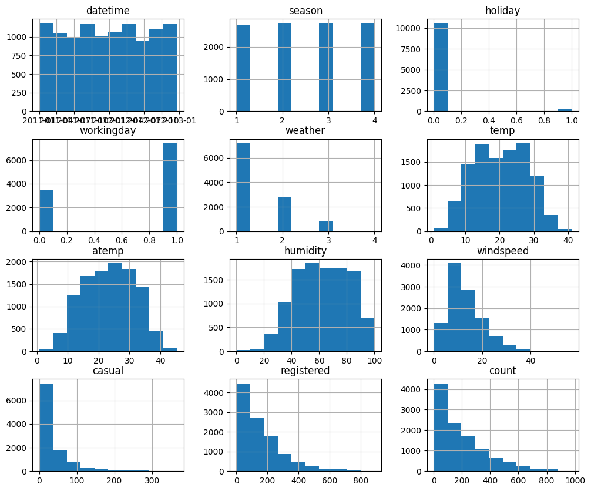

```python
# Create a histogram of all features to show the distribution of each one relative to the data. This is part of the exploritory data analysis
train.hist(figsize=(12, 10))
```

```python
# create a new feature
train['hour'] = train['datetime'].dt.hour
test['hour'] = test['datetime'].dt.hour
```

## Make category types for these so models know they are not just numbers

- AutoGluon originally sees these as ints, but in reality they are int representations of a category.
- Setting the dtype to category will classify these as categories in AutoGluon.

```python
train["season"] = train["season"].astype('category')
train["weather"] = train["weather"].astype('category')
test["season"] = test["season"].astype('category')
test["weather"] = test["weather"].astype('category')
```

```python
# View are new feature
train.head()
```

|  | datetime | season | holiday | workingday | weather | temp | atemp | humidity | windspeed | casual | registered | count | hour |
| --- | --- | --- | --- | --- | --- | --- | --- | --- | --- | --- | --- | --- | --- |
| 0 | 2011-01-01 00:00:00 | 1 | 0 | 0 | 1 | 9.84 | 14.395 | 81 | 0.0 | 3 | 13 | 16 | 0 |
| 1 | 2011-01-01 01:00:00 | 1 | 0 | 0 | 1 | 9.02 | 13.635 | 80 | 0.0 | 8 | 32 | 40 | 1 |
| 2 | 2011-01-01 02:00:00 | 1 | 0 | 0 | 1 | 9.02 | 13.635 | 80 | 0.0 | 5 | 27 | 32 | 2 |
| 3 | 2011-01-01 03:00:00 | 1 | 0 | 0 | 1 | 9.84 | 14.395 | 75 | 0.0 | 3 | 10 | 13 | 3 |
| 4 | 2011-01-01 04:00:00 | 1 | 0 | 0 | 1 | 9.84 | 14.395 | 75 | 0.0 | 0 | 1 | 1 | 4 |

```
array([[<Axes: title={'center': 'datetime'}>,
        <Axes: title={'center': 'holiday'}>,
        <Axes: title={'center': 'workingday'}>],
       [<Axes: title={'center': 'temp'}>,
        <Axes: title={'center': 'atemp'}>,
        <Axes: title={'center': 'humidity'}>],
       [<Axes: title={'center': 'windspeed'}>,
        <Axes: title={'center': 'casual'}>,
        <Axes: title={'center': 'registered'}>],
       [<Axes: title={'center': 'count'}>,
        <Axes: title={'center': 'hour'}>, <Axes: >]], dtype=object)
```

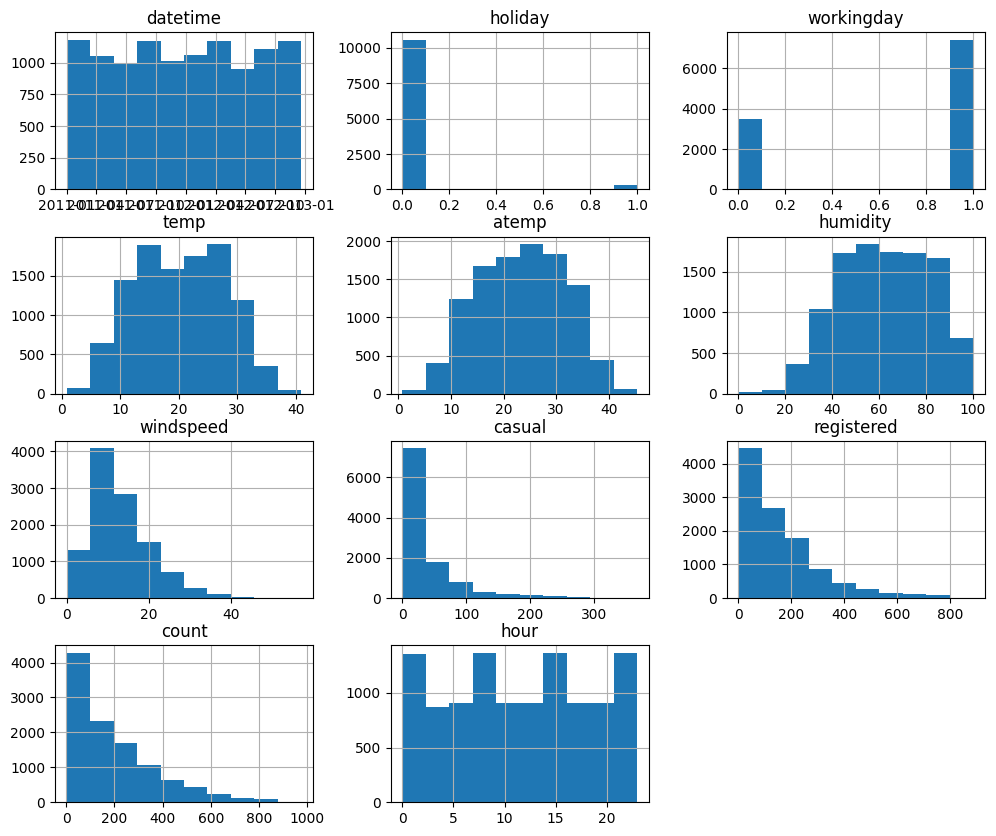

```python
# View histogram of all features again now with the hour feature
train.hist(figsize=(12,10))
```

## Step 5: Rerun the model with the same settings as before, just with more features

```python
train.describe()
```

|  | datetime | holiday | workingday | temp | atemp | humidity | windspeed | casual | registered | count | hour |
| --- | --- | --- | --- | --- | --- | --- | --- | --- | --- | --- | --- |
| count | 10886 | 10886.000000 | 10886.000000 | 10886.00000 | 10886.000000 | 10886.000000 | 10886.000000 | 10886.000000 | 10886.000000 | 10886.000000 | 10886.000000 |
| mean | 2011-12-27 05:56:22.399411968 | 0.028569 | 0.680875 | 20.23086 | 23.655084 | 61.886460 | 12.799395 | 36.021955 | 155.552177 | 191.574132 | 11.541613 |
| min | 2011-01-01 00:00:00 | 0.000000 | 0.000000 | 0.82000 | 0.760000 | 0.000000 | 0.000000 | 0.000000 | 0.000000 | 1.000000 | 0.000000 |
| 25% | 2011-07-02 07:15:00 | 0.000000 | 0.000000 | 13.94000 | 16.665000 | 47.000000 | 7.001500 | 4.000000 | 36.000000 | 42.000000 | 6.000000 |
| 50% | 2012-01-01 20:30:00 | 0.000000 | 1.000000 | 20.50000 | 24.240000 | 62.000000 | 12.998000 | 17.000000 | 118.000000 | 145.000000 | 12.000000 |
| 75% | 2012-07-01 12:45:00 | 0.000000 | 1.000000 | 26.24000 | 31.060000 | 77.000000 | 16.997900 | 49.000000 | 222.000000 | 284.000000 | 18.000000 |
| max | 2012-12-19 23:00:00 | 1.000000 | 1.000000 | 41.00000 | 45.455000 | 100.000000 | 56.996900 | 367.000000 | 886.000000 | 977.000000 | 23.000000 |
| std | NaN | 0.166599 | 0.466159 | 7.79159 | 8.474601 | 19.245033 | 8.164537 | 49.960477 | 151.039033 | 181.144454 | 6.915838 |

```python
train_data = train.drop(columns=['casual','registered'])
predictor_new_features = TabularPredictor(label='count', eval_metric='root_mean_squared_error').fit(
    train_data=train_data,
    time_limit=600,
    presets='best_quality'
)
```

[output not shown]

[output cut: 33 more lines]

```
	'XT': [{'criterion': 'gini', 'ag_args': {'name_suffix': 'Gini', 'problem_types': ['binary', 'multiclass']}}, {'criterion': 'entropy', 'ag_args': {'name_suffix': 'Entr', 'problem_types': ['binary', 'multiclass']}}, {'criterion': 'squared_error', 'ag_args': {'name_suffix': 'MSE', 'problem_types': ['r…
	'KNN': [{'weights': 'uniform', 'ag_args': {'name_suffix': 'Unif'}}, {'weights': 'distance', 'ag_args': {'name_suffix': 'Dist'}}],
}
AutoGluon will fit 2 stack levels (L1 to L2) ...
Fitting 108 L1 models, fit_strategy="sequential" ...
Fitting model: KNeighborsUnif_BAG_L1 ... Training model for up to 99.78s of the 149.67s of remaining time.
	-107.445	 = Validation score   (-root_mean_squared_error)
	0.03s	 = Training   runtime
	0.09s	 = Validation runtime
Fitting model: KNeighborsDist_BAG_L1 ... Training model for up to 99.63s of the 149.52s of remaining time.
	-89.9469	 = Validation score   (-root_mean_squared_error)
	0.03s	 = Training   runtime
	0.08s	 = Validation runtime
Fitting model: LightGBMXT_BAG_L1 ... Training model for up to 99.50s of the 149.38s of remaining time.
	Fitting 8 child models (S1F1 - S1F8) | Fitting with SequentialLocalFoldFittingStrategy
```

[output not shown]

[output not shown]

[output cut: 68 more lines]

```
	'XT': [{'criterion': 'gini', 'ag_args': {'name_suffix': 'Gini', 'problem_types': ['binary', 'multiclass']}}, {'criterion': 'entropy', 'ag_args': {'name_suffix': 'Entr', 'problem_types': ['binary', 'multiclass']}}, {'criterion': 'squared_error', 'ag_args': {'name_suffix': 'MSE', 'problem_types': ['r…
	'KNN': [{'weights': 'uniform', 'ag_args': {'name_suffix': 'Unif'}}, {'weights': 'distance', 'ag_args': {'name_suffix': 'Dist'}}],
}
AutoGluon will fit 2 stack levels (L1 to L2) ...
Fitting 108 L1 models, fit_strategy="sequential" ...
Fitting model: KNeighborsUnif_BAG_L1 ... Training model for up to 281.28s of the 422.00s of remaining time.
	-101.5462	 = Validation score   (-root_mean_squared_error)
	0.06s	 = Training   runtime
	0.08s	 = Validation runtime
Fitting model: KNeighborsDist_BAG_L1 ... Training model for up to 281.11s of the 421.83s of remaining time.
	-84.1251	 = Validation score   (-root_mean_squared_error)
	0.05s	 = Training   runtime
	0.09s	 = Validation runtime
Fitting model: LightGBMXT_BAG_L1 ... Training model for up to 280.93s of the 421.65s of remaining time.
	Fitting 8 child models (S1F1 - S1F8) | Fitting with SequentialLocalFoldFittingStrategy
```

[output not shown]

```
	-34.4573	 = Validation score   (-root_mean_squared_error)
	72.28s	 = Training   runtime
	14.47s	 = Validation runtime
Fitting model: LightGBM_BAG_L1 ... Training model for up to 186.99s of the 327.72s of remaining time.
	Fitting 8 child models (S1F1 - S1F8) | Fitting with SequentialLocalFoldFittingStrategy
```

```
[1000]	valid_set's rmse: 33.1807
[2000]	valid_set's rmse: 33.0157
[1000]	valid_set's rmse: 32.8606
[2000]	valid_set's rmse: 32.6361
[1000]	valid_set's rmse: 31.9551
[2000]	valid_set's rmse: 31.3427
[3000]	valid_set's rmse: 30.9071
[4000]	valid_set's rmse: 30.8642
[1000]	valid_set's rmse: 35.8651
[2000]	valid_set's rmse: 35.4992
[3000]	valid_set's rmse: 35.4249
[1000]	valid_set's rmse: 35.5385
[1000]	valid_set's rmse: 31.6267
[1000]	valid_set's rmse: 37.9271
[2000]	valid_set's rmse: 37.4486
[1000]	valid_set's rmse: 34.9425
[2000]	valid_set's rmse: 34.6699
```

[output not shown]

```
[1000]	valid_set's rmse: 35.126
[1000]	valid_set's rmse: 29.549
[1000]	valid_set's rmse: 31.1367
[1000]	valid_set's rmse: 30.6995
```

[output not shown]

```python
predictor_new_features.fit_summary()
```

```
*** Summary of fit() ***
Estimated performance of each model:
                     model   score_val              eval_metric  pred_time_val    fit_time  pred_time_val_marginal  fit_time_marginal  stack_level  can_infer  fit_order
0      WeightedEnsemble_L3  -30.463228  root_mean_squared_error      22.208163  363.757952                0.000711           0.042945            3       True         15
1          LightGBM_BAG_L2  -30.743577  root_mean_squared_error      20.111048  260.173002                0.253389          11.954215            2       True         11
2        LightGBMXT_BAG_L2  -31.208856  root_mean_squared_error      20.885301  266.572480                1.027642          18.353692            2       True         10
3     ExtraTreesMSE_BAG_L2  -31.587981  root_mean_squared_error      20.633404  262.710181                0.775746          14.491394            2       True         13
4   RandomForestMSE_BAG_L2  -31.915329  root_mean_squared_error      20.636482  299.874559                0.778823          51.655771            2       True         12
5   NeuralNetFastAI_BAG_L2  -32.174615  root_mean_squared_error      20.147597  281.751328                0.289939          33.532541            2       True         14
6      WeightedEnsemble_L2  -32.308929  root_mean_squared_error      18.863081  132.621560                0.000880           0.035220            2       True          9
7          LightGBM_BAG_L1  -33.919639  root_mean_squared_error       3.042469   26.028996                3.042469          26.028996            1       True          4
8        LightGBMXT_BAG_L1  -34.457274  root_mean_squared_error      14.469308   72.282720               14.469308          72.282720            1       True          3
9           XGBoost_BAG_L1  -35.367356  root_mean_squared_error       0.596163   14.715619                0.596163          14.715619            1       True          8
10    ExtraTreesMSE_BAG_L1  -38.326129  root_mean_squared_error       0.655767    9.184092                0.655767           9.184092            1       True          6
11  RandomForestMSE_BAG_L1  -38.454338  root_mean_squared_error       0.665858   19.505203                0.665858          19.505203            1       True          5
12  NeuralNetFastAI_BAG_L1  -46.610340  root_mean_squared_error       0.263485  106.392181                0.263485         106.392181            1       True          7
13   KNeighborsDist_BAG_L1  -84.125061  root_mean_squared_error       0.088403    0.053802                0.088403           0.053802            1       True          2
14   KNeighborsUnif_BAG_L1 -101.546199  root_mean_squared_error       0.076206    0.056175                0.076206           0.056175            1       True          1
Number of models trained: 15
Types of models trained:
{'StackerEnsembleModel_KNN', 'StackerEnsembleModel_RF', 'WeightedEnsembleModel', 'StackerEnsembleModel_XT', 'StackerEnsembleModel_XGBoost', 'StackerEnsembleModel_NNFastAiTabular', 'StackerEnsembleModel_LGB'}
Bagging used: True  (with 8 folds)
Multi-layer stack-ensembling used: True  (with 3 levels)
Feature Metadata (Processed):
(raw dtype, special dtypes):
('category', [])             : 2 | ['season', 'weather']
('float', [])                : 3 | ['temp', 'atemp', 'windspeed']
('int', [])                  : 2 | ['humidity', 'hour']
('int', ['bool'])            : 2 | ['holiday', 'workingday']
('int', ['datetime_as_int']) : 5 | ['datetime', 'datetime.year', 'datetime.month', 'datetime.day', 'datetime.dayofweek']
Plot summary of models saved to file: /content/AutogluonModels/ag-20250527_071349/SummaryOfModels.html
*** End of fit() summary ***
```

[output not shown]

[output cut: 199 more lines]

```
 0             3       True         15
 1             2       True         11
 2             2       True         10
 3             2       True         13
 4             2       True         12
 5             2       True         14
 6             2       True          9
 7             1       True          4
 8             1       True          3
 9             1       True          8
 10            1       True          6
 11            1       True          5
 12            1       True          7
 13            1       True          2
 14            1       True          1  }
```

```python
predictions_new_features = predictor_new_features.predict(test)
predictions_new_features.head()
```

|  | count |
| --- | --- |
| 0 | 15.350017 |
| 1 | 10.221979 |
| 2 | 9.443587 |
| 3 | 8.165311 |
| 4 | 7.308321 |

**dtype:** float32

```python
# Remember to set all negative values to zero
predictions_new_features.describe()
(predictions_new_features<0).sum()
```

```
np.int64(0)
```

```python
predictions_new_features = predictions_new_features.clip(lower=0)
```

```python
submission_new_features= pd.read_csv('sampleSubmission.csv',parse_dates=['datetime'])
submission.head()
```

|  | datetime | count |
| --- | --- | --- |
| 0 | 2011-01-20 00:00:00 | 23.148926 |
| 1 | 2011-01-20 01:00:00 | 42.324280 |
| 2 | 2011-01-20 02:00:00 | 46.433525 |
| 3 | 2011-01-20 03:00:00 | 48.170090 |
| 4 | 2011-01-20 04:00:00 | 51.108425 |

```python
# Same submitting predictions
submission_new_features["count"] = predictions_new_features
submission_new_features.to_csv("submission_new_features.csv", index=False)
```

```python
!kaggle competitions submit -c bike-sharing-demand -f submission_new_features.csv -m "new features_with train_data updated"
```

```
100% 188k/188k [00:00<00:00, 337kB/s]
Successfully submitted to Bike Sharing Demand
```

```python
!kaggle competitions submissions -c bike-sharing-demand | tail -n +1 | head -n 6
```

```
fileName                     date                        description                           status                     publicScore  privateScore
---------------------------  --------------------------  ------------------------------------  -------------------------  -----------  ------------
submission_new_features.csv  2025-05-27 07:26:57.560000  new features_with train_data updated  SubmissionStatus.COMPLETE  0.61099      0.61099
submission.csv               2025-05-27 07:08:37.633000  initial_submission_final              SubmissionStatus.COMPLETE  1.80356      1.80356
submission_new_hpo.csv       2025-05-26 17:51:10.943000  new features with hyperparameters     SubmissionStatus.COMPLETE  1.44163      1.44163
submission_new_hpo.csv       2025-05-26 16:18:36.547000  new features with hyperparameters     SubmissionStatus.COMPLETE  1.85673      1.85673
```

## Step 6: Hyper parameter optimization

- There are many options for hyper parameter optimization.
- Options are to change the AutoGluon higher level parameters or the individual model hyperparameters.
- The hyperparameters of the models themselves that are in AutoGluon. Those need the `hyperparameter` and `hyperparameter_tune_kwargs` arguments.

```python
from autogluon.tabular import TabularPredictor
from autogluon.common import space

# Define manual hyperparameter search space
hyperparameters = {
    'GBM': {
        'learning_rate': space.Real(0.01, 0.1),   # Try values between 0.01 and 0.1
        'max_depth': space.Int(3, 10),            # Try integer depths from 3 to 10
    },
    'CAT': {
        'learning_rate': space.Real(0.01, 0.1),
        'depth': space.Int(3, 10),
    },
    'XGB': {
        'learning_rate': space.Real(0.01, 0.1),
        'max_depth': space.Int(3, 10),
    },
    'RF': {}  # Random Forest - no tuning
}

# Fit with HPO using manual hyperparameters
predictor_new_hpo = TabularPredictor(label='count', eval_metric='root_mean_squared_error').fit(
    train_data=train_data,
    time_limit=600,  # Optional: adjust as per your time limit
    presets='best_quality',
    hyperparameter_tune_kwargs={
        'scheduler': 'local',  # Optional: ‘bayesopt’ also available
        'searcher': 'auto',    # Let AutoGluon choose the search algorithm
        'num_trials': 10       # Number of trials to explore combinations
    },
    hyperparameters=hyperparameters,
    verbosity=2
)
```

[output not shown]

[output cut: 20 more lines]

```
	Train Data (Processed) Memory Usage: 0.74 MB (0.0% of available memory)
Data preprocessing and feature engineering runtime = 0.15s ...
AutoGluon will gauge predictive performance using evaluation metric: 'root_mean_squared_error'
	This metric's sign has been flipped to adhere to being higher_is_better. The metric score can be multiplied by -1 to get the metric value.
	To change this, specify the eval_metric parameter of Predictor()
User-specified model hyperparameters to be fit:
{
	'GBM': [{'learning_rate': Real: lower=0.01, upper=0.1, 'max_depth': Int: lower=3, upper=10}],
	'CAT': [{'learning_rate': Real: lower=0.01, upper=0.1, 'depth': Int: lower=3, upper=10}],
	'XGB': [{'learning_rate': Real: lower=0.01, upper=0.1, 'max_depth': Int: lower=3, upper=10}],
	'RF': [{}],
}
AutoGluon will fit 2 stack levels (L1 to L2) ...
Fitting 4 L1 models, fit_strategy="sequential" ...
Hyperparameter tuning model: LightGBM_BAG_L1 ... Tuning model for up to 22.47s of the 149.84s of remaining time.
```

```
	Fitting 8 child models (S1F1 - S1F8) | Fitting with SequentialLocalFoldFittingStrategy
```

```
[1000]	valid_set's rmse: 72.1914
```

```
	Ran out of time, early stopping on iteration 1417. Best iteration is:
	[1417]	valid_set's rmse: 62.767
```

```
[1000]	valid_set's rmse: 63.1005
[2000]	valid_set's rmse: 52.0537
```

```
	Ran out of time, early stopping on iteration 2411. Best iteration is:
	[2411]	valid_set's rmse: 50.4594
```

```
[1000]	valid_set's rmse: 65.86
[2000]	valid_set's rmse: 55.4738
```

```
	Ran out of time, early stopping on iteration 2682. Best iteration is:
	[2682]	valid_set's rmse: 53.1604
	Fitting 8 child models (S1F1 - S1F8) | Fitting with SequentialLocalFoldFittingStrategy
	Ran out of time, early stopping on iteration 1055. Best iteration is:
	[1052]	valid_set's rmse: 35.1658
```

```
[1000]	valid_set's rmse: 35.2282
```

[output not shown]

[output not shown]

[output cut: 347 more lines]

[output not shown]

```
	Fitting 8 child models (S1F1 - S1F8) | Fitting with SequentialLocalFoldFittingStrategy
	Stopping HPO to satisfy time limit...
Fitted model: XGBoost_BAG_L1/T1 ...
	-63.2571	 = Validation score   (-root_mean_squared_error)
	19.68s	 = Training   runtime
	0.64s	 = Validation runtime
Fitting model: WeightedEnsemble_L2 ... Training model for up to 149.85s of the 89.45s of remaining time.
	Ensemble Weights: {'LightGBM_BAG_L1/T6': 0.765, 'RandomForest_BAG_L1': 0.235}
	-35.2387	 = Validation score   (-root_mean_squared_error)
	0.02s	 = Training   runtime
	0.0s	 = Validation runtime
Fitting 4 L2 models, fit_strategy="sequential" ...
Hyperparameter tuning model: LightGBM_BAG_L2 ... Tuning model for up to 20.12s of the 89.42s of remaining time.
```

```
	Fitting 8 child models (S1F1 - S1F8) | Fitting with SequentialLocalFoldFittingStrategy
```

```
[1000]	valid_set's rmse: 33.7649
[1000]	valid_set's rmse: 37.1736
[2000]	valid_set's rmse: 37.0856
[3000]	valid_set's rmse: 37.0676
[1000]	valid_set's rmse: 37.4939
```

```
	Stopping HPO to satisfy time limit...
Fitted model: LightGBM_BAG_L2/T1 ...
	-35.5944	 = Validation score   (-root_mean_squared_error)
	12.35s	 = Training   runtime
	0.51s	 = Validation runtime
Hyperparameter tuning model: RandomForest_BAG_L2 ... Tuning model for up to 20.12s of the 77.0s of remaining time.
	No hyperparameter search space specified for RandomForest_BAG_L2. Skipping HPO. Will train one model based on the provided hyperparameters.
Fitted model: RandomForest_BAG_L2 ...
	-36.0037	 = Validation score   (-root_mean_squared_error)
	30.87s	 = Training   runtime
	0.69s	 = Validation runtime
Hyperparameter tuning model: CatBoost_BAG_L2 ... Tuning model for up to 20.12s of the 46.1s of remaining time.
```

[output not shown]

[output cut: 347 more lines]

[output not shown]

[output not shown]

[output cut: 27 more lines]

```
	Train Data (Processed) Memory Usage: 0.83 MB (0.0% of available memory)
Data preprocessing and feature engineering runtime = 0.18s ...
AutoGluon will gauge predictive performance using evaluation metric: 'root_mean_squared_error'
	This metric's sign has been flipped to adhere to being higher_is_better. The metric score can be multiplied by -1 to get the metric value.
	To change this, specify the eval_metric parameter of Predictor()
User-specified model hyperparameters to be fit:
{
	'GBM': [{'learning_rate': Real: lower=0.01, upper=0.1, 'max_depth': Int: lower=3, upper=10}],
	'CAT': [{'learning_rate': Real: lower=0.01, upper=0.1, 'depth': Int: lower=3, upper=10}],
	'XGB': [{'learning_rate': Real: lower=0.01, upper=0.1, 'max_depth': Int: lower=3, upper=10}],
	'RF': [{}],
}
AutoGluon will fit 2 stack levels (L1 to L2) ...
Fitting 4 L1 models, fit_strategy="sequential" ...
Hyperparameter tuning model: LightGBM_BAG_L1 ... Tuning model for up to 71.33s of the 475.68s of remaining time.
```

```
	Fitting 8 child models (S1F1 - S1F8) | Fitting with SequentialLocalFoldFittingStrategy
```

```
[1000]	valid_set's rmse: 68.8534
[2000]	valid_set's rmse: 55.0183
[3000]	valid_set's rmse: 51.0242
[4000]	valid_set's rmse: 49.0069
[5000]	valid_set's rmse: 47.351
[6000]	valid_set's rmse: 46.5528
[7000]	valid_set's rmse: 45.8839
[8000]	valid_set's rmse: 45.3103
[9000]	valid_set's rmse: 44.5948
```

```
	Ran out of time, early stopping on iteration 9955. Best iteration is:
	[9954]	valid_set's rmse: 44.0677
	Fitting 8 child models (S1F1 - S1F8) | Fitting with SequentialLocalFoldFittingStrategy
```

```
[1000]	valid_set's rmse: 33.2649
[1000]	valid_set's rmse: 34.5282
[2000]	valid_set's rmse: 33.7996
[3000]	valid_set's rmse: 33.7515
[1000]	valid_set's rmse: 34.1742
[2000]	valid_set's rmse: 33.1874
[3000]	valid_set's rmse: 32.7714
[4000]	valid_set's rmse: 32.7721
[1000]	valid_set's rmse: 35.626
[2000]	valid_set's rmse: 34.9549
[1000]	valid_set's rmse: 38.4088
[2000]	valid_set's rmse: 37.8937
[1000]	valid_set's rmse: 32.8341
[1000]	valid_set's rmse: 37.6114
[2000]	valid_set's rmse: 37.1074
[3000]	valid_set's rmse: 36.9691
[4000]	valid_set's rmse: 36.9615
[1000]	valid_set's rmse: 32.8487
[2000]	valid_set's rmse: 32.3552
[3000]	valid_set's rmse: 32.3023
```

```
	Fitting 8 child models (S1F1 - S1F8) | Fitting with SequentialLocalFoldFittingStrategy
```

```
[1000]	valid_set's rmse: 32.1121
[1000]	valid_set's rmse: 33.1649
```

```
	Ran out of time, early stopping on iteration 1630. Best iteration is:
	[1626]	valid_set's rmse: 32.8028
```

```
[1000]	valid_set's rmse: 32.5242
[2000]	valid_set's rmse: 31.6186
```

[output not shown]

[output not shown]

[output cut: 347 more lines]

[output not shown]

```
	Fitting 8 child models (S1F1 - S1F8) | Fitting with SequentialLocalFoldFittingStrategy
	Stopping HPO to satisfy time limit...
Fitted model: XGBoost_BAG_L1/T1 ...
	-49.2692	 = Validation score   (-root_mean_squared_error)
	64.81s	 = Training   runtime
	3.46s	 = Validation runtime
Fitting model: WeightedEnsemble_L2 ... Training model for up to 360.00s of the 322.00s of remaining time.
	Ensemble Weights: {'LightGBM_BAG_L1/T2': 0.706, 'RandomForest_BAG_L1': 0.294}
	-33.3897	 = Validation score   (-root_mean_squared_error)
	0.02s	 = Training   runtime
	0.0s	 = Validation runtime
Fitting 4 L2 models, fit_strategy="sequential" ...
Hyperparameter tuning model: LightGBM_BAG_L2 ... Tuning model for up to 72.44s of the 321.96s of remaining time.
```

```
	Fitting 8 child models (S1F1 - S1F8) | Fitting with SequentialLocalFoldFittingStrategy
```

```
[1000]	valid_set's rmse: 35.984
[1000]	valid_set's rmse: 36.0988
[2000]	valid_set's rmse: 35.955
[3000]	valid_set's rmse: 36.0212
[1000]	valid_set's rmse: 32.3611
[1000]	valid_set's rmse: 31.1198
[1000]	valid_set's rmse: 33.5007
```

[output not shown]

[output not shown]

[output cut: 347 more lines]

[output not shown]

[output not shown]

```python
leaderboard_df = predictor_new_hpo.leaderboard()
best_model = leaderboard_df.iloc[0]['model']
print("Best model:", best_model)
```

```
Best model: WeightedEnsemble_L3
```

```python
# This gives you the summary of training + best models + best hyperparameters
predictor_new_hpo.fit_summary()
```

```
*** Summary of fit() ***
Estimated performance of each model:
                  model   score_val              eval_metric  pred_time_val    fit_time  pred_time_val_marginal  fit_time_marginal  stack_level  can_infer  fit_order
0   WeightedEnsemble_L3  -33.307457  root_mean_squared_error       9.105358  191.423350                0.001002           0.058868            3       True         19
1   WeightedEnsemble_L2  -33.389710  root_mean_squared_error       4.076150   53.743091                0.000706           0.019757            2       True          5
2    LightGBM_BAG_L2/T1  -33.475032  root_mean_squared_error       8.131323  135.104037                0.545099          13.038959            2       True          6
3     XGBoost_BAG_L2/T1  -33.698494  root_mean_squared_error       7.891419  138.740054                0.305196          16.674976            2       True         14
4    LightGBM_BAG_L2/T3  -33.728445  root_mean_squared_error       7.691739  130.299201                0.105515           8.234123            2       True          8
5    LightGBM_BAG_L2/T2  -33.744966  root_mean_squared_error       7.661010  129.271112                0.074786           7.206034            2       True          7
6     XGBoost_BAG_L2/T4  -33.767607  root_mean_squared_error       7.699499  128.916245                0.113276           6.851167            2       True         17
7    LightGBM_BAG_L2/T4  -33.801281  root_mean_squared_error       7.671917  130.909257                0.085694           8.844179            2       True          9
8    LightGBM_BAG_L2/T5  -33.860245  root_mean_squared_error       7.737854  131.938334                0.151631           9.873256            2       True         10
9    LightGBM_BAG_L2/T7  -33.909027  root_mean_squared_error       7.669756  130.320479                0.083533           8.255401            2       True         12
10    XGBoost_BAG_L2/T2  -34.146617  root_mean_squared_error       7.718354  133.132074                0.132130          11.066996            2       True         15
11  RandomForest_BAG_L2  -34.157628  root_mean_squared_error       8.368047  161.247221                0.781824          39.182143            2       True         13
12   LightGBM_BAG_L2/T6  -34.273964  root_mean_squared_error       7.659541  131.478175                0.073318           9.413097            2       True         11
13   LightGBM_BAG_L1/T2  -34.317686  root_mean_squared_error       3.387408   31.743185                3.387408          31.743185            1       True          1
14    XGBoost_BAG_L2/T3  -34.493664  root_mean_squared_error       7.755422  142.686992                0.169199          20.621914            2       True         16
15    XGBoost_BAG_L2/T5  -34.672580  root_mean_squared_error       7.764333  133.826266                0.178110          11.761188            2       True         18
16  RandomForest_BAG_L1  -38.454338  root_mean_squared_error       0.688036   21.980149                0.688036          21.980149            1       True          3
17    XGBoost_BAG_L1/T1  -49.269236  root_mean_squared_error       3.462879   64.812167                3.462879          64.812167            1       True          4
18   LightGBM_BAG_L1/T8 -143.643008  root_mean_squared_error       0.047900    3.529577                0.047900           3.529577            1       True          2
Number of models trained: 19
Types of models trained:
{'StackerEnsembleModel_LGB', 'StackerEnsembleModel_XGBoost', 'StackerEnsembleModel_RF', 'WeightedEnsembleModel'}
Bagging used: True  (with 8 folds)
Multi-layer stack-ensembling used: True  (with 3 levels)
Feature Metadata (Processed):
(raw dtype, special dtypes):
('category', [])             : 2 | ['season', 'weather']
('float', [])                : 3 | ['temp', 'atemp', 'windspeed']
('int', [])                  : 2 | ['humidity', 'hour']
('int', ['bool'])            : 2 | ['holiday', 'workingday']
('int', ['datetime_as_int']) : 5 | ['datetime', 'datetime.year', 'datetime.month', 'datetime.day', 'datetime.dayofweek']
Plot summary of models saved to file: /content/AutogluonModels/ag-20250527_072743/SummaryOfModels.html
*** End of fit() summary ***
```

[output not shown]

[output cut: 259 more lines]

[output not shown]

```python
predictions_new_hpo = predictor_new_hpo.predict(test)
predictions_new_hpo.head()
```

|  | count |
| --- | --- |
| 0 | 13.371216 |
| 1 | 6.008911 |
| 2 | 5.348645 |
| 3 | 4.594690 |
| 4 | 4.589590 |

**dtype:** float32

```python
# Remember to set all negative values to zero
predictions_new_hpo.describe()
(predictions_new_hpo<0).sum()
```

```
np.int64(0)
```

```python
submission_new_hpo= pd.read_csv('sampleSubmission.csv',parse_dates=['datetime'])
submission_new_hpo.head()
```

|  | datetime | count |
| --- | --- | --- |
| 0 | 2011-01-20 00:00:00 | 0 |
| 1 | 2011-01-20 01:00:00 | 0 |
| 2 | 2011-01-20 02:00:00 | 0 |
| 3 | 2011-01-20 03:00:00 | 0 |
| 4 | 2011-01-20 04:00:00 | 0 |

```python
# Same submitting predictions
submission_new_hpo["count"] = predictions_new_hpo
submission_new_hpo.to_csv("submission_new_hpo.csv", index=False)
```

```python
!kaggle competitions submit -c bike-sharing-demand -f submission_new_hpo.csv -m "new features with hyperparameters(after_editing_train_data)"
```

```
100% 188k/188k [00:00<00:00, 333kB/s]
Successfully submitted to Bike Sharing Demand
```

```python
!kaggle competitions submissions -c bike-sharing-demand | tail -n +1 | head -n 6
```

```
fileName                     date                        description                                                  status                     publicScore  privateScore
---------------------------  --------------------------  -----------------------------------------------------------  -------------------------  -----------  ------------
submission_new_hpo.csv       2025-05-27 07:38:13.253000  new features with hyperparameters(after_editing_train_data)  SubmissionStatus.COMPLETE  0.46817      0.46817
submission_new_hpo.csv       2025-05-27 07:37:37.740000  new features with hyperparameters                            SubmissionStatus.COMPLETE  0.46817      0.46817
submission_new_features.csv  2025-05-27 07:26:57.560000  new features_with train_data updated                         SubmissionStatus.COMPLETE  0.61099      0.61099
submission.csv               2025-05-27 07:08:37.633000  initial_submission_final                                     SubmissionStatus.COMPLETE  1.80356      1.80356
```